# Cardiocvascular Disease Prediction

## DataSource : Kaggle[[sulianova](https://www.kaggle.com/sulianova/cardiovascular-disease-dataset)]

**Team** -  
[BL.EN.U4AIE19007] *Apoorva Mani*  
[BL.EN.U4AIE19010] *Bhuvanashree Murugadoss*  
[BL.EN.U4AIE19027] *Karna Sai Nikhilesh Reddy*

# Importing Dependencies

```python
import sys # Not Required
import warnings
import os
import pickle
import numpy as np
import pandas as pd
import matplotlib as mpl
from matplotlib import pyplot as plt
from pandas.plotting import scatter_matrix
import seaborn as sns

from sklearn.base import BaseEstimator, TransformerMixin
from sklearn.impute import SimpleImputer
from sklearn.model_selection import train_test_split, StratifiedShuffleSplit, cross_val_score, GridSearchCV, KFold
from sklearn.preprocessing import OneHotEncoder, StandardScaler
from sklearn.pipeline import Pipeline, FeatureUnion
from sklearn.metrics import accuracy_score, classification_report, confusion_matrix, plot_confusion_matrix

# Machine Learning Algorithms
from sklearn.linear_model import LogisticRegression
from sklearn.naive_bayes import GaussianNB
from sklearn.neighbors import KNeighborsClassifier
from sklearn.svm import SVC
from sklearn.tree import DecisionTreeClassifier
from sklearn.ensemble import BaggingClassifier
from sklearn.tree import DecisionTreeClassifier
from sklearn.ensemble import VotingClassifier
from sklearn.ensemble import RandomForestClassifier

# Ignoring Warnings
warnings.filterwarnings(action='ignore')

# Fixing matplotlib inline and label sizes
%matplotlib inline
mpl.rc('axes', labelsize=14)
mpl.rc('xtick', labelsize=12)
mpl.rc('ytick', labelsize=12)
```

# File Locations for Images, Dataset, Pickles and Models

```python
# Root Directory
PROJECT_ROOT_DIR = os.getcwd()

# Dataset Directory
DATASET_NAME = 'cardiovascular-disease-dataset.csv'
DATASET_DIR = 'datasets'
DATASET_PATH = os.path.join(PROJECT_ROOT_DIR, DATASET_DIR)


def load_dataset(path=DATASET_PATH, filename=DATASET_NAME, sep=';'):
    dataset_location = os.path.join(path, filename)
    return pd.read_csv(dataset_location, sep)


# Pickle and Model Directory
PM_DIR = 'Pickles_And_Models'
PM_PATH = os.path.join(PROJECT_ROOT_DIR, PM_DIR)
os.makedirs(PM_PATH, exist_ok=True)

def save_object(object_ , pickle_name, pm_path = PM_PATH):
    path = os.path.join(pm_path, pickle_name)
    pickle.dump(object_, open(path, 'wb'))
    print('Saving Pickle', path)

def load_object(pickle_name, pm_path = PM_PATH):
    path = os.path.join(pm_path, pickle_name)
    object_ = pickle.load(open(path, 'rb'))
    print('Loaded Pickle', path)
    return object_
```

# Load Dataset

```python
cardio = load_dataset()
cardio.columns
```

```
Index(['id', 'age', 'gender', 'height', 'weight', 'ap_hi', 'ap_lo',
       'cholesterol', 'gluc', 'smoke', 'alco', 'active', 'cardio'],
      dtype='object')
```

```python
cardio.drop('id', axis=1, inplace=True)
save_object(cardio, 'Initial_cardio.dataframe')
cardio.head()
```

```
Saving Pickle E:\Github\SEMESTER-3\PML_Project\Pickles_And_Models\Initial_cardio.dataframe
```

|  | age | gender | height | weight | ap_hi | ap_lo | cholesterol | gluc | smoke | alco | active | cardio |
| --- | --- | --- | --- | --- | --- | --- | --- | --- | --- | --- | --- | --- |
| 0 | 18393 | 2 | 168 | 62.0 | 110 | 80 | 1 | 1 | 0 | 0 | 1 | 0 |
| 1 | 20228 | 1 | 156 | 85.0 | 140 | 90 | 3 | 1 | 0 | 0 | 1 | 1 |
| 2 | 18857 | 1 | 165 | 64.0 | 130 | 70 | 3 | 1 | 0 | 0 | 0 | 1 |
| 3 | 17623 | 2 | 169 | 82.0 | 150 | 100 | 1 | 1 | 0 | 0 | 1 | 1 |
| 4 | 17474 | 1 | 156 | 56.0 | 100 | 60 | 1 | 1 | 0 | 0 | 0 | 0 |

# Basic Data Information

```python
cardio.info()
```

```
<class 'pandas.core.frame.DataFrame'>
RangeIndex: 70000 entries, 0 to 69999
Data columns (total 12 columns):
 #   Column       Non-Null Count  Dtype
---  ------       --------------  -----
 0   age          70000 non-null  int64
 1   gender       70000 non-null  int64
 2   height       70000 non-null  int64
 3   weight       70000 non-null  float64
 4   ap_hi        70000 non-null  int64
 5   ap_lo        70000 non-null  int64
 6   cholesterol  70000 non-null  int64
 7   gluc         70000 non-null  int64
 8   smoke        70000 non-null  int64
 9   alco         70000 non-null  int64
 10  active       70000 non-null  int64
 11  cardio       70000 non-null  int64
dtypes: float64(1), int64(11)
memory usage: 6.4 MB
```

```python
cardio.describe(include='all')
```

|  | age | gender | height | weight | ap_hi | ap_lo | cholesterol | gluc | smoke | alco | active | cardio |
| --- | --- | --- | --- | --- | --- | --- | --- | --- | --- | --- | --- | --- |
| count | 70000.000000 | 70000.000000 | 70000.000000 | 70000.000000 | 70000.000000 | 70000.000000 | 70000.000000 | 70000.000000 | 70000.000000 | 70000.000000 | 70000.000000 | 70000.000000 |
| mean | 19468.865814 | 1.349571 | 164.359229 | 74.205690 | 128.817286 | 96.630414 | 1.366871 | 1.226457 | 0.088129 | 0.053771 | 0.803729 | 0.499700 |
| std | 2467.251667 | 0.476838 | 8.210126 | 14.395757 | 154.011419 | 188.472530 | 0.680250 | 0.572270 | 0.283484 | 0.225568 | 0.397179 | 0.500003 |
| min | 10798.000000 | 1.000000 | 55.000000 | 10.000000 | -150.000000 | -70.000000 | 1.000000 | 1.000000 | 0.000000 | 0.000000 | 0.000000 | 0.000000 |
| 25% | 17664.000000 | 1.000000 | 159.000000 | 65.000000 | 120.000000 | 80.000000 | 1.000000 | 1.000000 | 0.000000 | 0.000000 | 1.000000 | 0.000000 |
| 50% | 19703.000000 | 1.000000 | 165.000000 | 72.000000 | 120.000000 | 80.000000 | 1.000000 | 1.000000 | 0.000000 | 0.000000 | 1.000000 | 0.000000 |
| 75% | 21327.000000 | 2.000000 | 170.000000 | 82.000000 | 140.000000 | 90.000000 | 2.000000 | 1.000000 | 0.000000 | 0.000000 | 1.000000 | 1.000000 |
| max | 23713.000000 | 2.000000 | 250.000000 | 200.000000 | 16020.000000 | 11000.000000 | 3.000000 | 3.000000 | 1.000000 | 1.000000 | 1.000000 | 1.000000 |

## Checking for Null Values

```python
cardio[cardio.isnull().any(axis=1)]
## We can see that there were no null values in dataset, we will move further with Duplicate values
```

|  | age | gender | height | weight | ap_hi | ap_lo | cholesterol | gluc | smoke | alco | active | cardio |
| --- | --- | --- | --- | --- | --- | --- | --- | --- | --- | --- | --- | --- |

## Checking for Duplicate Values

```python
cardio_duplicate_values = cardio[cardio.duplicated(keep=False)]
print('Shape of duplicates :',cardio_duplicate_values.shape)
cardio_duplicate_values.sort_values(by=['age']).head()
```

```
Shape of duplicates : (48, 12)
```

|  | age | gender | height | weight | ap_hi | ap_lo | cholesterol | gluc | smoke | alco | active | cardio |
| --- | --- | --- | --- | --- | --- | --- | --- | --- | --- | --- | --- | --- |
| 40365 | 14552 | 1 | 158 | 64.0 | 120 | 80 | 1 | 1 | 0 | 0 | 1 | 0 |
| 6325 | 14552 | 1 | 158 | 64.0 | 120 | 80 | 1 | 1 | 0 | 0 | 1 | 0 |
| 64169 | 16160 | 1 | 168 | 65.0 | 120 | 80 | 1 | 1 | 0 | 0 | 1 | 1 |
| 17101 | 16160 | 1 | 168 | 65.0 | 120 | 80 | 1 | 1 | 0 | 0 | 1 | 1 |
| 1204 | 16793 | 1 | 165 | 68.0 | 120 | 80 | 1 | 1 | 0 | 0 | 1 | 0 |

```python
# We can observe that 24 instances were being duplicated, we will try to remove them from dataset
cardio.drop(index=cardio[cardio.duplicated()].index, axis=0, inplace=True)
print('After removing duplicates :', cardio.shape)
```

```
After removing duplicates : (69976, 12)
```

# Outliers Detection

```
Saving figure E:\Github\SEMESTER-3\PML_Project\images\Outliers_Found.png
```

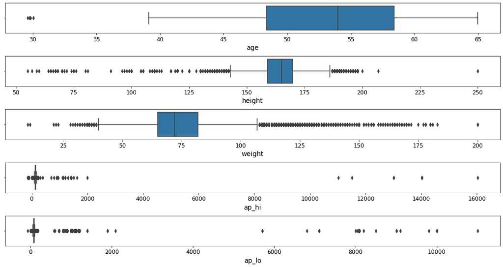

```python
# Outliers Detection
continuous_features = ['age', 'height', 'weight', 'ap_hi', 'ap_lo']
fig, axes = plt.subplots(nrows=len(continuous_features), ncols=1, figsize =(15,8));

sns.boxplot(cardio['age']/365, ax=axes[0])

for (index, column) in enumerate(continuous_features[1:], 1):
    sns.boxplot(cardio[column], ax=axes[index])

save_fig('Outliers_Found')
plt.show()
```

```python
# We will do manual adjustment/deletion instead of zscore method due to it being medical data

cardio.drop(cardio[(cardio['height'] < 80) | (cardio['height'] > 220)].index, inplace=True)
cardio.drop(cardio[cardio['weight'] < 35].index, inplace=True)
cardio.drop(cardio[(cardio['ap_hi'] < 50) | (cardio['ap_hi'] > 225)].index, inplace=True)
cardio.drop(cardio[(cardio['ap_lo'] < 50) | (cardio['ap_lo'] > 180)].index, inplace=True)
```

```
Saving figure E:\Github\SEMESTER-3\PML_Project\images\Outliers_Removed.png
```

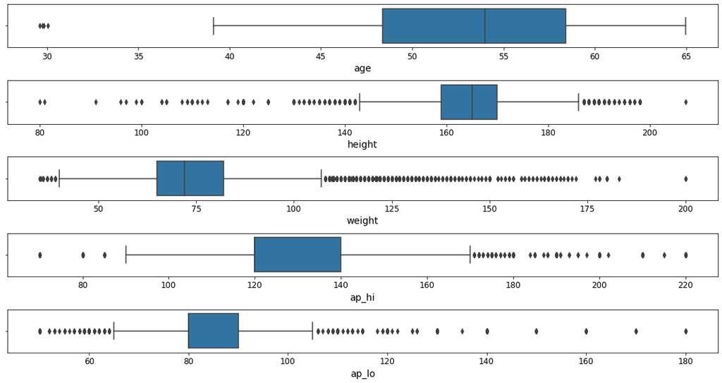

```python
# Outliers Detection
continuous_features = ['age', 'height', 'weight', 'ap_hi', 'ap_lo']
fig, axes = plt.subplots(nrows=len(continuous_features), ncols=1, figsize =(15,8));

sns.boxplot(cardio['age']/365, ax=axes[0])

for (index, column) in enumerate(continuous_features[1:], 1):
    sns.boxplot(cardio[column], ax=axes[index])

save_fig('Outliers_Removed')
plt.show()
```

We can observe that after implementing Outlier removal we have got more useful data. Majority of the Outliers presented in **ap_hi**, **ap_lo** and **height** columns.

# Histogram for all features each with 50 bins

```
Saving figure E:\Github\SEMESTER-3\PML_Project\images\Cardio_Histogram_Full.png
```

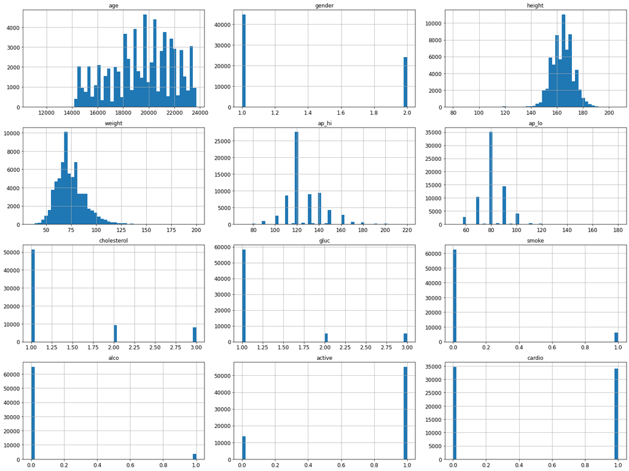

```python
cardio.hist(bins=50, figsize=(20,15))
save_fig('Cardio_Histogram_Full')
plt.show()
```

From the above plots, we have observed that **Cholesterol** and **Glucose** have each 3 classes in them. We have to seperate them into different columns.

# Distributions of Categorical Features

```
Saving figure E:\Github\SEMESTER-3\PML_Project\images\Categorical_Features_Comparison.png
```

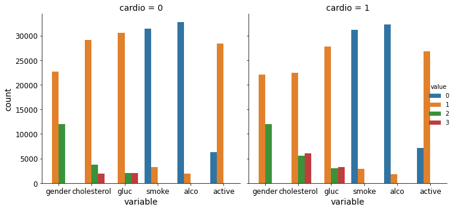

```python
cat_features = ['gender','cholesterol','gluc', 'smoke', 'alco', 'active']
df_long = pd.melt(cardio, id_vars=['cardio'], value_vars=cat_features)
sns.catplot(x="variable", hue="value", col="cardio",data=df_long, kind="count")
save_fig('Categorical_Features_Comparison')
plt.show()
```

```
Saving figure E:\Github\SEMESTER-3\PML_Project\images\BMI_vs_Gender_Category_Analysis.png
```

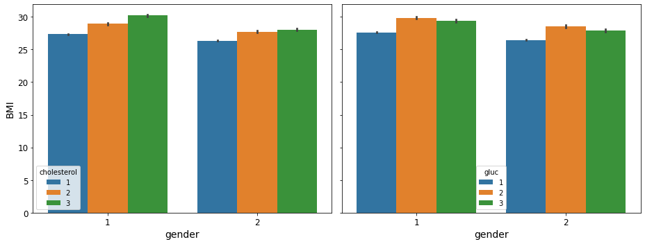

```python
cat_column = ['cholesterol','gluc']

fig, axes = plt.subplots(nrows=1, ncols=len(cat_column), figsize =(13,5), sharey=True)
fig.subplots_adjust(hspace=0.4, wspace=0.4)
BMI = cardio['weight']/((cardio['height']/100)**2)

for (index, column) in enumerate(cat_column):
    sns.barplot(x='gender',y=BMI, data=cardio, hue=column, ax=axes[index])

axes[0].set_ylabel('BMI')
save_fig('BMI_vs_Gender_Category_Analysis')
plt.show()
```

# Dataset Splitting

### Splitting of Cardio Dataset into training and testing set with Stratified Shuffle Split method

```python
save_object(cardio, 'Final_cardio.dataframe')
```

```
Saving Pickle E:\Github\SEMESTER-3\PML_Project\Pickles_And_Models\Final_cardio.dataframe
```

```python
cardio['age_cat'] = pd.cut(cardio['age'],
                           bins=[0, 16000, 18000, 20000, 21000, 22000, 23000, np.inf],
                           labels=[1 , 2, 3, 4, 5, 6, 7])
cardio['age_cat'].value_counts()
```

```
3    20111
5    11292
2     9859
4     8319
1     8035
6     6249
7     4816
Name: age_cat, dtype: int64
```

```
Saving figure E:\Github\SEMESTER-3\PML_Project\images\Age_Distribution_vs_Categories.png
```

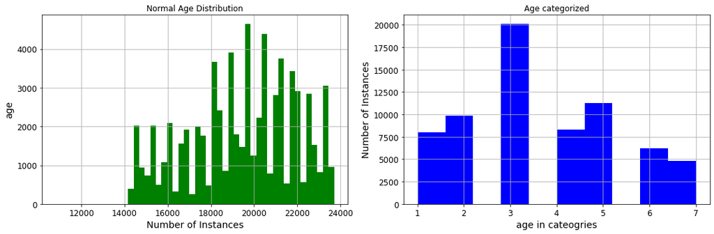

```python
fig, axes = plt.subplots(nrows=1, ncols=2, figsize=(15,5))

cardio['age'].hist(bins=50, ax=axes[0], color='g')
axes[0].set(title= 'Normal Age Distribution', xlabel='Number of Instances', ylabel='age')

cardio['age_cat'].hist(ax=axes[1], color='b')
axes[1].set(title= 'Age categorized', xlabel='age in cateogries', ylabel='Number of Instances')

save_fig('Age_Distribution_vs_Categories')
plt.show()
```

cardio_train, cardio_test = train_test_split(cardio, test_size=0.2)

fig, split = plt.subplots(nrows=1, ncols=2, figsize=(15,5))

save_object(cardio, 'qwicksave.data')

```python
strat_split = StratifiedShuffleSplit(n_splits=1, test_size=0.2, random_state=42)
for train_index, test_index in strat_split.split(cardio, cardio['age_cat']):
    strat_train_set = cardio.iloc[train_index]
    strat_test_set  = cardio.iloc[test_index]
```

```
Saving figure E:\Github\SEMESTER-3\PML_Project\images\Stratified_Train_Test_Set.png
```

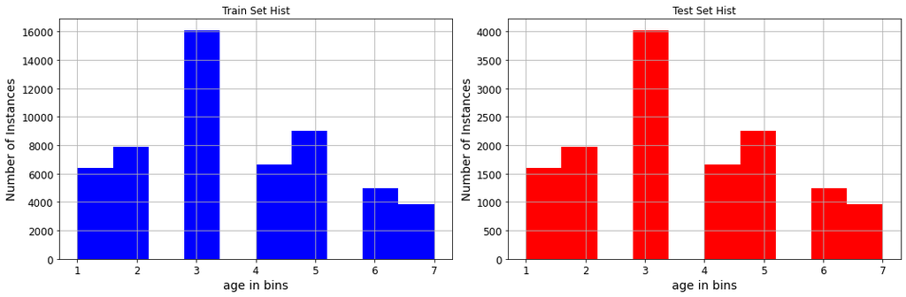

```python
fig, strat = plt.subplots(nrows=1, ncols=2, figsize=(15,5))

strat_train_set['age_cat'].hist(ax=strat[0], color='b')
strat[0].set(title= 'Train Set Hist', xlabel='age in bins', ylabel='Number of Instances')

strat_test_set['age_cat'].hist(ax=strat[1], color='r')
strat[1].set(title= 'Test Set Hist', xlabel='age in bins', ylabel='Number of Instances')

save_fig('Stratified_Train_Test_Set')
plt.show()
```

```python
for set_ in (strat_train_set, strat_test_set):
    set_.drop('age_cat', axis=1, inplace=True)
```

```python
cardio = strat_train_set.copy()
```

```python
corr_matrix = cardio.corr()
```

```python
corr_matrix['cardio'].sort_values(ascending=False)
```

```
cardio         1.000000
ap_hi          0.427615
ap_lo          0.339710
age            0.239476
cholesterol    0.219276
weight         0.176428
gluc           0.091428
gender         0.006667
alco          -0.008415
height        -0.013512
smoke         -0.014269
active        -0.038482
Name: cardio, dtype: float64
```

```
Saving figure E:\Github\SEMESTER-3\PML_Project\images\Heat_Map_General.png
```

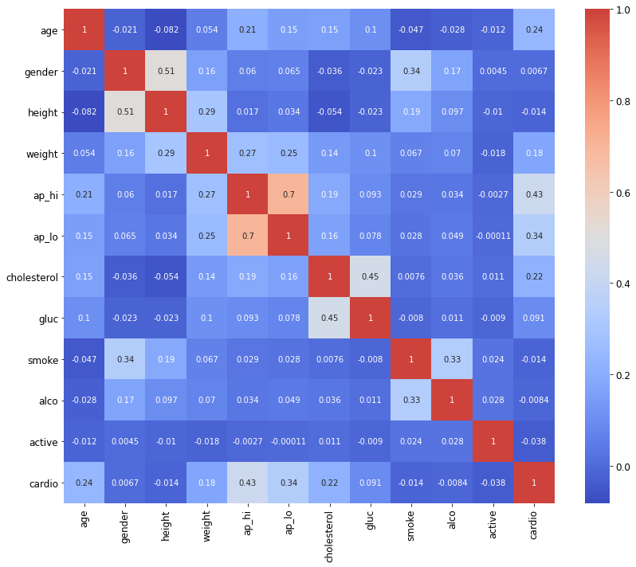

```python
# Correlation HeatMap
fig, axes = plt.subplots(1,1,figsize=(12,10))
sns.heatmap(corr_matrix, annot=True, cmap='coolwarm', ax=axes, center=0.5)
save_fig('Heat_Map_General')
plt.show()
```

As we can see that the data is not very much correlated, so we proceed further with Data Tranformation Pipelines

```python
# save_object(strat_train_set.drop(columns='cardio',axis=1), 'strat_train_cardio.dataframe')
# save_object(strat_train_set['cardio'], 'strat_train_cardio_labels.dataframe')
# save_object(strat_test_set.drop(columns='cardio',axis=1), 'strat_test_cardio.dataframe')
# save_object(strat_test_set['cardio'], 'strat_test_cardio_labels.dataframe')

# cardio = strat_train_set.drop(columns='cardio',axis=1).copy()
# cardio_labels = strat_train_set['cardio'].copy()
```

# Data Transformation Pipelines

```python
cardio = load_object('Final_cardio.dataframe')

X_train = load_object('strat_train_cardio.dataframe')
y_train = load_object('strat_train_cardio_labels.dataframe')

X_test = load_object('strat_test_cardio.dataframe')
y_test = load_object('strat_test_cardio_labels.dataframe')
```

```
Loaded Pickle /content/Pickles_And_Models/Final_cardio.dataframe
Loaded Pickle /content/Pickles_And_Models/strat_train_cardio.dataframe
Loaded Pickle /content/Pickles_And_Models/strat_train_cardio_labels.dataframe
Loaded Pickle /content/Pickles_And_Models/strat_test_cardio.dataframe
Loaded Pickle /content/Pickles_And_Models/strat_test_cardio_labels.dataframe
```

```python
class DataFrameSelector(BaseEstimator, TransformerMixin):

    def __init__(self, attribute_names):
        self.attribute_names = attribute_names

    def fit(self, X, y=None):
        return self

    def transform(self, X):
        return X[self.attribute_names].values

target_feature = ['cardio']
cat_attributes = ['cholesterol', 'gluc']
num_attributes = ['age', 'gender', 'height', 'weight', 'ap_hi', 'ap_lo', 'smoke', 'alco', 'active']
new_cat_attributes = ['cholesterol_1', 'cholesterol_2', 'cholesterol_3', 'gluc_1', 'gluc_2', 'gluc_3']

num_pipeline = Pipeline([
    ('selector'  , DataFrameSelector(num_attributes)),
    ('imputer'   , SimpleImputer(strategy='median')),
    ('std_scaler', StandardScaler())
])

cat_pipeline = Pipeline([
    ('selector'    , DataFrameSelector(cat_attributes)),
    ('cat_encoder' , OneHotEncoder(sparse=False))
])

full_pipeline = FeatureUnion(transformer_list=[
    ('Numerical_Pipeline', num_pipeline),
    ('Categorical_Pipeline', cat_pipeline)
])
```

```python
X_train.head(2)
```

|  | age | gender | height | weight | ap_hi | ap_lo | cholesterol | gluc | smoke | alco | active |
| --- | --- | --- | --- | --- | --- | --- | --- | --- | --- | --- | --- |
| 3280 | 22640 | 2 | 167 | 78.0 | 160 | 100 | 1 | 1 | 0 | 0 | 1 |
| 40230 | 20613 | 1 | 156 | 88.0 | 150 | 80 | 1 | 1 | 0 | 0 | 1 |

```python
full_pipeline.fit(X_train)
```

```
FeatureUnion(n_jobs=None,
             transformer_list=[('Numerical_Pipeline',
                                Pipeline(memory=None,
                                         steps=[('selector',
                                                 DataFrameSelector(attribute_names=['age',
                                                                                    'gender',
                                                                                    'height',
                                                                                    'weight',
                                                                                    'ap_hi',
                                                                                    'ap_lo',
                                                                                    'smoke',
                                                                                    'alco',
                                                                                    'active'])),
                                                ('imputer',
                                                 SimpleImputer(add_indicator=False,
                                                               copy=True,
                                                               fill_value=None,
                                                               missing_values=nan,
                                                               strategy='median',
                                                               verbose=0)),
                                                ('std_scaler',...
                                                                with_mean=True,
                                                                with_std=True))],
                                         verbose=False)),
                               ('Categorical_Pipeline',
                                Pipeline(memory=None,
                                         steps=[('selector',
                                                 DataFrameSelector(attribute_names=['cholesterol',
                                                                                    'gluc'])),
                                                ('cat_encoder',
                                                 OneHotEncoder(categories='auto',
                                                               drop=None,
                                                               dtype=<class 'numpy.float64'>,
                                                               handle_unknown='error',
                                                               sparse=False))],
                                         verbose=False))],
             transformer_weights=None, verbose=False)
```

```python
save_object(full_pipeline, 'full_pipeline.transformer')
```

```
Saving Pickle /content/Pickles_And_Models/full_pipeline.transformer
```

```python
X_train = pd.DataFrame(data=full_pipeline.transform(X_train), columns=num_attributes+new_cat_attributes)
X_test = pd.DataFrame(data=full_pipeline.transform(X_test), columns=num_attributes+new_cat_attributes)
```

```python
X_train.head(2)
```

|  | age | gender | height | weight | ap_hi | ap_lo | smoke | alco | active | cholesterol_1 | cholesterol_2 | cholesterol_3 | gluc_1 | gluc_2 | gluc_3 |
| --- | --- | --- | --- | --- | --- | --- | --- | --- | --- | --- | --- | --- | --- | --- | --- |
| 0 | 1.286661 | 1.371339 | 0.325114 | 0.266796 | 1.997143 | 1.941350 | -0.310522 | -0.237641 | 0.494967 | 1.0 | 0.0 | 0.0 | 1.0 | 0.0 | 0.0 |
| 1 | 0.465335 | -0.729214 | -1.048238 | 0.965196 | 1.398966 | -0.143682 | -0.310522 | -0.237641 | 0.494967 | 1.0 | 0.0 | 0.0 | 1.0 | 0.0 | 0.0 |

# Machine Learning Algorithms Implementation

## Logistic Regression

```python
grid_values={
    "C" : [0.001,0.01,1,5,10,25,50],
    "penalty" : ["l1","l2"]
}

grid_search=GridSearchCV(LogisticRegression(),grid_values,cv=10)
grid_search.fit(X_train,y_train)

print("tuned hpyerparameters :(best parameters) ",grid_search.best_params_)
print("accuracy :",grid_search.best_score_)
```

```
tuned hpyerparameters :(best parameters)  {'C': 25, 'penalty': 'l2'}
accuracy : 0.7276502482814405
```

```python
#Training the model with the optimised parameters
log_reg = LogisticRegression(C = 25, penalty = 'l2')
log_reg.fit(X_train, y_train)

#KFold cross-validation for evaluating the model
cv = KFold(n_splits=10, random_state=1, shuffle=True)
scores = cross_val_score(log_reg, X_train, y_train, scoring='recall', cv=cv, n_jobs=-1)

# Reporting the performance
print('Accuracy: %.3f | Scores: (%.3f)' % (np.mean(scores), np.std(scores)))
```

```
Accuracy: 0.669 | Scores: (0.009)
```

```python
# Testing Set
log_reg = LogisticRegression(C = 25, penalty = 'l2')
log_reg.fit(X_train, y_train)
log_pred_test = log_reg.predict(X_test)
print('Testing dataset')
print(confusion_matrix(y_test,log_pred_test))
print(classification_report(y_test,log_pred_test))
print(accuracy_score(y_test,log_pred_test))
```

```
Testing dataset
[[5505 1550]
 [2142 4540]]
              precision    recall  f1-score   support

           0       0.72      0.78      0.75      7055
           1       0.75      0.68      0.71      6682

    accuracy                           0.73     13737
   macro avg       0.73      0.73      0.73     13737
weighted avg       0.73      0.73      0.73     13737

0.731236805707214
```

```
Saving figure E:\Github\SEMESTER-3\PML_Project\images\Confusion_matrix_Logisitic.png
```

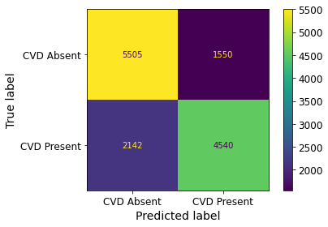

```python
plot_confusion_matrix(log_reg, X_test, y_test, display_labels = ['CVD Absent', 'CVD Present'])
save_fig('Confusion_matrix_Logisitic')
plt.show()
```

```python
save_object(log_reg, 'Logistic_Regression.model')
```

```
Saving Pickle E:\Github\SEMESTER-3\PML_Project\Pickles_And_Models\Logistic_Regression.model
```

# Naive Bayes

```python
gauss_nb = GaussianNB()
gauss_nb.fit(X_train, y_train)
gnb_pred_test = gauss_nb.predict(X_test)

print('Testing dataset')
print(confusion_matrix(y_test,gnb_pred_test))
print(classification_report(y_test,gnb_pred_test))
print(accuracy_score(y_test,gnb_pred_test))
```

```
Testing dataset
[[5488 1567]
 [2968 3714]]
              precision    recall  f1-score   support

           0       0.65      0.78      0.71      7055
           1       0.70      0.56      0.62      6682

    accuracy                           0.67     13737
   macro avg       0.68      0.67      0.66     13737
weighted avg       0.68      0.67      0.67     13737

0.6698696949843488
```

```
Saving figure E:\Github\SEMESTER-3\PML_Project\images\Confusion_matrix_Naive_Bayes.png
```

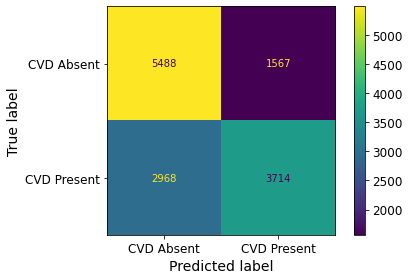

```python
plot_confusion_matrix(gauss_nb, X_test, y_test, display_labels = ['CVD Absent', 'CVD Present'])
save_fig('Confusion_matrix_Naive_Bayes')
plt.show()
```

```python
save_object(gauss_nb, 'Naive_Bayes.model')
```

```
Saving Pickle E:\Github\SEMESTER-3\PML_Project\Pickles_And_Models\Naive_Bayes.model
```

# K Nearest Neighbors

```python
hyperparameters={
    "n_neighbors" : [1, 5, 10, 25, 50, 75],
    "p" : [1, 2] # manhattan_distance (l1), and euclidean_distance (l2)
}

grid_search=GridSearchCV(KNeighborsClassifier(),hyperparameters,cv=10, verbose=1, n_jobs=-1)
grid_search.fit(X_train,y_train)

print("tuned hpyerparameters :(best parameters) ",grid_search.best_params_)
print("accuracy :",grid_search.best_score_)
```

```
Fitting 10 folds for each of 12 candidates, totalling 120 fits
```

```
[Parallel(n_jobs=-1)]: Using backend LokyBackend with 8 concurrent workers.
[Parallel(n_jobs=-1)]: Done  34 tasks      | elapsed:  1.1min
[Parallel(n_jobs=-1)]: Done 120 out of 120 | elapsed:  4.6min finished
```

```
tuned hpyerparameters :(best parameters)  {'n_neighbors': 75, 'p': 1}
accuracy : 0.7289059087703583
```

```python
#Training the model with the optimised parameters
knn = KNeighborsClassifier(n_neighbors = 75, p = 1)
knn.fit(X_train, y_train)

#KFold cross-validation for evaluating the model
cv = KFold(n_splits=10, random_state=1, shuffle=True)
scores = cross_val_score(knn, X_train, y_train, scoring='accuracy', cv=cv, n_jobs=-1)

# Reporting the performance
print('Scores -> Mean: %.3f | STD: (%.3f)' % (np.mean(scores), np.std(scores)))
```

```
Scores -> Mean: 0.728 | STD: (0.005)
```

```python
# Testing Set
knn = KNeighborsClassifier(n_neighbors = 25, p = 1)
knn.fit(X_train, y_train)
knn_pred_test = knn.predict(X_test)
print('Testing dataset')
print(confusion_matrix(y_test,knn_pred_test))
print(classification_report(y_test,knn_pred_test))
print(accuracy_score(y_test,knn_pred_test))
```

```
Testing dataset
[[5346 1709]
 [2069 4613]]
              precision    recall  f1-score   support

           0       0.72      0.76      0.74      7055
           1       0.73      0.69      0.71      6682

    accuracy                           0.72     13737
   macro avg       0.73      0.72      0.72     13737
weighted avg       0.73      0.72      0.72     13737

0.7249763412681081
```

```
Saving figure E:\Github\SEMESTER-3\PML_Project\images\Confusion_Matrix_KNN.png
```

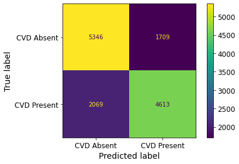

```python
plot_confusion_matrix(knn, X_test, y_test, display_labels = ['CVD Absent', 'CVD Present'])
save_fig('Confusion_Matrix_KNN')
plt.show()
```

```python
save_object(knn, 'KNN.model')
```

```
Saving Pickle E:\Github\SEMESTER-3\PML_Project\Pickles_And_Models\KNN.model
```

# Support Vector Machines (SVM)

```python
'''
hyperparameters={
    "C" : [0.1, 10],
    "gamma" : [0.1, 1],
    "kernel" : ['linear']
}

grid_search=GridSearchCV(SVC(), hyperparameters,cv=2, verbose=1, n_jobs=-1)
grid_search.fit(X_train,y_train)

print("tuned hpyerparameters :(best parameters) ",grid_search.best_params_)
print("accuracy :",grid_search.best_score_)

'''
```

[output not shown]

```python
#Training the model with the optimised parameters
svm = SVC(C=0.1, gamma=1, kernel='linear')
svm.fit(X_train, y_train)

#KFold cross-validation for evaluating the model
cv = KFold(n_splits=5, random_state=1, shuffle=True)
scores = cross_val_score(svm, X_train, y_train, scoring='accuracy', cv=cv, n_jobs=-1)

# Reporting the performance
print('Scores -> Mean: %.3f | STD: (%.3f)' % (np.mean(scores), np.std(scores)))
```

[output not shown]

```python
svm = SVC(C=0.1, gamma=1, kernel='linear')
svm.fit(X_train, y_train)
```

```python
svm_pred_test = svm.predict(X_test)
print('Testing dataset')
print(confusion_matrix(y_test,svm_pred_test))
print(classification_report(y_test,svm_pred_test))
print(accuracy_score(y_test,svm_pred_test))
```

```
Testing dataset
[[5744 1311]
 [2387 4295]]
              precision    recall  f1-score   support

           0       0.71      0.81      0.76      7055
           1       0.77      0.64      0.70      6682

    accuracy                           0.73     13737
   macro avg       0.74      0.73      0.73     13737
weighted avg       0.74      0.73      0.73     13737

0.7308000291184392
```

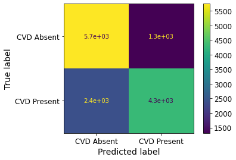

```python
plot_confusion_matrix(svm, X_test, y_test, display_labels = ['CVD Absent', 'CVD Present'])
plt.show()
```

```python
save_object(svm, 'SVM.model')
```

```
Saving Pickle /content/Pickles_And_Models/SVM.model
```

# Decision Trees

```python
#Training the model with the default parameters
tree_clf = DecisionTreeClassifier()
tree_clf.fit(X_train,y_train)

#KFold cross-validation for evaluating the model
cv = KFold(n_splits=10, random_state=1, shuffle=True)
scores = cross_val_score(tree_clf, X_train,y_train, scoring='accuracy', cv=cv, n_jobs=-1)

# Reporting the performance
print('Accuracy: %.3f (%.3f)' % (np.mean(scores), np.std(scores)))
```

```
Accuracy: 0.633 (0.005)
```

```python
pipeline = Pipeline([('clf',tree_clf)])
parameters = {
    'clf__max_depth': np.linspace(1,10,10),
    'clf__min_samples_split': (1,2,3,4,5),
    'clf__min_samples_leaf': (1,2,3,4,5)
}
grid_search = GridSearchCV(pipeline, parameters, n_jobs=-1)
grid_search.fit(X_train,y_train)

grid_search.best_score_
```

[output not shown]

```python
best_parameters = grid_search.best_estimator_.get_params()
for param_name in sorted(parameters.keys()):
    print(f'{param_name} : {best_parameters[param_name]}')
```

[output not shown]

```python
#Training the model with the optimised parameters
tree_clf = DecisionTreeClassifier(max_depth=5,min_samples_leaf=1,min_samples_split=2)
tree_clf.fit(X_train,y_train)

#KFold cross-validation for evaluating the model
cv = KFold(n_splits=10, random_state=1, shuffle=True)
scores = cross_val_score(tree_clf, X_train,y_train, scoring='accuracy', cv=cv, n_jobs=-1)

# Reporting the performance
print('Accuracy: %.3f (%.3f)' % (np.mean(scores), np.std(scores)))
```

[output not shown]

```python
save_object(tree_clf, 'Decision_Tree.model')
```

```
Saving Pickle /content/Pickles_And_Models/Decision_Tree.model
```

# Ensemble Methods

```python
def plot_crossval_boxplot(models):
    outcome = []
    model_names = []

    for model_name, model in models:
        k_fold_validation = KFold(n_splits=10)
        results = cross_val_score(model, X_train, y_train, cv=k_fold_validation, scoring='accuracy')
        outcome.append(results)
        model_names.append(model_name)

    fig = plt.figure()
    fig.suptitle('Comparison of the Cross Validation Accuracy Scores')
    ax = fig.add_subplot(111)
    plt.boxplot(outcome)
    ax.set_xticklabels(model_names)
    plt.show()
```

# Bagging and Pasting Ensemble Methods

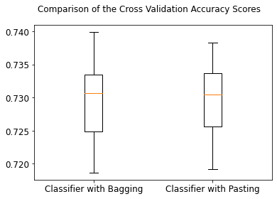

```python
#Bagging
bag_clf = BaggingClassifier(DecisionTreeClassifier(),
                            n_estimators=500,
                            max_samples=100,
                            bootstrap=True,
                            n_jobs=-1)

#Pasting
pas_clf = BaggingClassifier(DecisionTreeClassifier(),
                            n_estimators=500,
                            max_samples=100,
                            bootstrap=False,
                            n_jobs=-1)

bag_clf.fit(X_train, y_train)
pas_clf.fit(X_train, y_train)

plot_crossval_boxplot([('Classifier with Bagging',bag_clf), ('Classifier with Pasting',pas_clf)])
```

# Hard and Soft Voting in the Ensemble Method

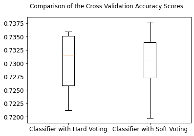

```python
#Warning - takes 3 mins to compile
hard_voting_clf = VotingClassifier(estimators=[('bagging', bag_clf), ('pasting', pas_clf)],voting='hard')
soft_voting_clf = VotingClassifier(estimators=[('bagging', bag_clf), ('pasting', pas_clf)],voting='soft')

hard_voting_clf.fit(X_train, y_train)
soft_voting_clf.fit(X_train, y_train)

plot_crossval_boxplot([('Classifier with Hard Voting',hard_voting_clf), ('Classifier with Soft Voting',soft_voting_clf)])
```

# Random Forest Classifier (Similar to Bagging with Decision Tree Algorithm)

```python
# Training the model with the default parameters
rf_clf = RandomForestClassifier()
rf_clf.fit(X_train, y_train)

# KFold cross-validation for evaluating the model
cv = KFold(n_splits=10, random_state=1, shuffle=True)
scores = cross_val_score(rf_clf, X_test, y_test, scoring='accuracy', cv=cv, n_jobs=-1)

# Reporting the performance
print('Accuracy: %.3f (%.3f)' % (np.mean(scores), np.std(scores)))
```

```
Accuracy: 0.717 (0.012)
```

```
<sklearn.metrics._plot.confusion_matrix.ConfusionMatrixDisplay at 0x7f0eec0bb588>
```

[figure not shown]

```python
#How well can the default paramters predict?
y_pred = rf_clf.predict(X_test)
plot_confusion_matrix(rf_clf, X_test, y_test, display_labels = ['CVD Present','CVD Absent'])
```

```python
# Warning takes 5 mins to compile
'''
pipeline = Pipeline([('clf',rf_clf)])
parameters = {
    'clf__max_depth': (1,2,3,4,5),
    'clf__min_samples_split': (1,2,3),
    'clf__min_samples_leaf': (1,2,3)
}
grid_search = GridSearchCV(pipeline, parameters, n_jobs=-1)
grid_search.fit(X_train,y_train)

grid_search.best_score_
Best score obtianed = 0.7297333333333335
'''
```

[output not shown]

```python
best_parameters = grid_search.best_estimator_.get_params()
for param_name in sorted(parameters.keys()):
  print(f'{param_name} : {best_parameters[param_name]}')

'''
Best Estimators obtained:
clf__max_depth : 5
clf__min_samples_leaf : 1
clf__min_samples_split : 2
'''
```

```python
#Training the model with the optimised parameters
rf_clf1 = RandomForestClassifier(max_depth=5,min_samples_leaf=1,min_samples_split=2)
rf_clf1.fit(X_train, y_train)

#KFold cross-validation for evaluating the model
cv = KFold(n_splits=10, random_state=1, shuffle=True)
scores = cross_val_score(rf_clf1, X_test, y_test, scoring='accuracy', cv=cv, n_jobs=-1)

# Reporting the performance
print('Accuracy: %.3f (%.3f)' % (np.mean(scores), np.std(scores)))
```

```
Accuracy: 0.728 (0.015)
```

```
<sklearn.metrics._plot.confusion_matrix.ConfusionMatrixDisplay at 0x7f0eebfe3cc0>
```

[figure not shown]

```python
#How well can the default paramters predict?
y_pred = rf_clf1.predict(X_test)
plot_confusion_matrix(rf_clf1, X_test, y_test, display_labels = ['CVD Present','CVD Absent'])
```

```python
save_object(rf_clf1, 'Random_Forest.model')
```

```
Saving Pickle /content/Pickles_And_Models/Random_Forest.model
```

# Model Analysis

```python
log_reg = load_object('Logistic_Regression.model')
gnb = load_object('Naive_Bayes.model')
knn = load_object('KNN.model')
svm = load_object('SVM.model')
decision_tree = load_object('Decision_Tree.model')
random_forest = load_object('Random_Forest.model')
```

```
Loaded Pickle /content/Pickles_And_Models/Logistic_Regression.model
Loaded Pickle /content/Pickles_And_Models/Naive_Bayes.model
Loaded Pickle /content/Pickles_And_Models/KNN.model
Loaded Pickle /content/Pickles_And_Models/SVM.model
Loaded Pickle /content/Pickles_And_Models/Decision_Tree.model
Loaded Pickle /content/Pickles_And_Models/Random_Forest.model
```

```python
models      = [log_reg, gnb, knn, svm, decision_tree, random_forest]
models_cols = ['Logistic_Regression', 'Naive_Bayes', 'KNN', 'Support_Vector_Machines', 'Decision_Tree', 'Random_Forest']
```

```python
predictions = [model.predict(X_test) for model in models]
conf_mat =[confusion_matrix(y_test, model_pred).reshape(1,-1).tolist()[0] for model_pred in predictions]
accuracy_score_table = [accuracy_score(y_test, model_pred) for model_pred in predictions]
```

```python
final_comparison = pd.DataFrame( data=conf_mat, index=models_cols , columns= ['True CVD Absent', 'False CVD Absent', 'False CVD Present', 'True CVD Present'] )
```

```python
final_comparison['accuracy_score'] = accuracy_score_table
```

```python
final_comparison.sort_values('accuracy_score', ascending=False)
```

|  | True CVD Absent | False CVD Absent | False CVD Present | True CVD Present | accuracy_score |
| --- | --- | --- | --- | --- | --- |
| Logistic_Regression | 5505 | 1550 | 2142 | 4540 | 0.731237 |
| Support_Vector_Machines | 5744 | 1311 | 2387 | 4295 | 0.730800 |
| Random_Forest | 5502 | 1553 | 2186 | 4496 | 0.727815 |
| KNN | 5346 | 1709 | 2069 | 4613 | 0.724976 |
| Naive_Bayes | 5488 | 1567 | 2968 | 3714 | 0.669870 |
| Decision_Tree | 4455 | 2600 | 2496 | 4186 | 0.629031 |